# Segmentação de Clientes aplicando *RFM score* (R)

Eudito Magul - Analista de Dados

4/24/2020

## 1.0 Nota Introdutória

A **segmentação de clientes** é essencial para alcançar um grupo específico de público, i.e, ajuda a alcançar as pessoas com quem a marca, produto e ou serviço realmente quer conversar, aumentando as chances de encontrar *leads* qualificados e gerar mais vendas.

Existem diferentes tipos de segmentação de clientes, definidos de acordo com as características de suas variáveis. O seu agrupamento pode conter elementos de apenas um tipo de segmentação ou, então, até mesmo combinar mais de um modelo para se chegar no perfil ideal para o trabalho comercial (vendas).

As comuns são: **geográfica** (quando a localização é factor chave para a decisão de compra), **demográficas** (costumam ser sexo, idade, estado civil, entre outros), **comportamentais** (gostos pessoais, preferências, comportamentos e hábitos) e **psicográficas** (atributos psicológicos, como: valores, estilo de vida e opiniões sobre temas relevantes).

### 1.1 Análise *RFM (Recency, Frequency and Monetary Value)*

A segmentação de clientes por *RFM* é uma técnica que avalia quais clientes são de maior e menor valor para uma organização, com base no tempo de retorno, na frequência e no valor monetário da compra, a fim de prever quais clientes têm maior probabilidade de fazer novamente compras no futuro. Este conceito é baseado na premissa de marketing de que $80\%$ da sua receita provém de $20\%$ de seus clientes. Esta técnica responde basicamente as três seguintes questões:

1. Qual foi a última vez que o cliente fez uma compra *(Recency)*?
2. Com que frequência faz as compras *(Frequency)*?
3. Quanto o cliente gasta *(Monetary Value)*?

## 2.0 Contextualização

Em uma situação onde uma determinada empresa representante de várias marcas de roupas e acessórios, desconhecia os seus clientes, potenciais clientes e quais clientes são valiosos para a empresa, a empresa decidiu dar um segmento a todos o seus clientes de forma a responder as seguintes questões:

1. Quem são os clientes mais valiosos da empresa?
2. Como pode-se adquirir novos clientes que se assemelham aos (clientes) mais valiosos?

### 2.0.1 Objectivo Principal

- **Analisar o comportamento e hábitos de pedidos de roupa e acessórios dos clientes**, de forma a **classificar** e **segmentar** em grupos.

Também seria interessante, para o presente caso identificar:

- Quais são os clientes mais/menos valiosos?
- Quais são os potenciais clientes valiosos?
- Quanto valor um cliente está a gerar para a organização?

Estas questões podem nos levar as seguintes percepções:

- Segmentar os clientes com base no seu valor;
- Monitorar a migração dos clientes entre os segmentos definidos.

### 2.0.2 Origem dos Dados

Os dados em análise são referentes a compras efectuadas no período de $2011$ a $2013$. Estes dados são meramente hipotéticos para efeitos de demonstração da técnica *RFM score Analysis*. Oportunamente com dados reais far-se-á um *post* seja em *Python* ou R para demonstrar o poder da técnica em classificação e segmentação de clientes. Contudo, para o presente estudo usar-se-á **R**.

## 3.0 Análise Exploratória

Parafraseando `John Wilder Tukey (1977)`, a análise exploratória é uma técnica que emprega grande variedade de técnicas quantitativas e gráficas visando maximizar a obtençao de informações das variáveis em causa.

Aplica-se esta etapa de forma a se familiarizar com o conjunto de dados que se tem por analisar.

```r
library(pander)
```

```r
library(tidyverse)
```

```r
library(highcharter)
df_sales <- readxl::read_xlsx("Sales.xlsx")
```

```r
df_sales %>% head() %>% pander()
```

| CustomerID | Total | Date |
| --- | --- | --- |
| 16250 | 6295 | 2011-01-01 |
| 17511 | 5148 | 2011-01-01 |
| 13448 | 6291 | 2011-01-01 |
| 15012 | 4708 | 2011-01-01 |
| 12472 | 2360 | 2011-01-01 |
| 18229 | 2780 | 2011-01-01 |

Primeiro, formata-se a data de forma a calcular correctamente, em seguida fixa-se uma data de referência para análise como sendo $01-01-2014$.

```r
# Converter em Formato Data (yyyy-mm-dd)
df_sales$Date <-
    as.Date(df_sales$Date, "%Y-%m-%d")
# Data de Referência
date_ref <- as.Date('2014-01-01')

df_sales$Duration <- as.numeric(
    difftime(
        time1 = date_ref,
        time2 = df_sales$Date,
        units = "days"
    )
)

# Dados após transformação
df_sales %>% head() %>% pander()
```

| CustomerID | Total | Date | Duration |
| --- | --- | --- | --- |
| 16250 | 6295 | 2011-01-01 | 1096 |
| 17511 | 5148 | 2011-01-01 | 1096 |
| 13448 | 6291 | 2011-01-01 | 1096 |
| 15012 | 4708 | 2011-01-01 | 1096 |
| 12472 | 2360 | 2011-01-01 | 1096 |
| 18229 | 2780 | 2011-01-01 | 1096 |

```r
library(sqldf)
```

Nesta etapa, criar-se-á colunas calculadas contendo valores específicos de *Recency*, *Frequency* e *Monetary*. Adicionar-se-á também uma coluna *Data_Purchase* que é diferença da data de referência e data que o cliente efectou a compra. E para poder-se adicionar as colunas usa-se o código *SQL*.

```r
# Compute recency, frequency, and average purchase amount
cust_df = sqldf(
    "SELECT CustomerID,
            MIN(Duration) AS 'Recency',
            MAX (Duration) AS Date_Purchase,
            COUNT(*) AS 'Frequency',
            SUM(Total) AS 'Monetary'
        FROM df_sales
        GROUP BY 1"
)

cust_df %>% head() %>% pander()
```

| CustomerID | Recency | Date_Purchase | Frequency | Monetary |
| --- | --- | --- | --- | --- |
| 12347 | 14 | 994 | 31 | 178001 |
| 12348 | 156 | 1031 | 17 | 76776 |
| 12370 | 11 | 1093 | 91 | 502537 |
| 12377 | 14 | 1079 | 43 | 222580 |
| 12386 | 236 | 1042 | 8 | 34223 |
| 12395 | 4 | 996 | 31 | 159825 |

Fazendo as estatísticas descritivas (sumarização) dos dados, tem-se:

```r
cust_df[,-1] %>% summary() %>% pander()
```

| Recency | Date_Purchase | Frequency | Monetary |
| --- | --- | --- | --- |
| Min. : 1.0 | Min. : 18 | Min. : 1.00 | Min. : 556 |
| 1st Qu.: 13.0 | 1st Qu.: 979 | 1st Qu.: 8.00 | 1st Qu.: 37494 |
| Median : 45.0 | Median :1054 | Median : 17.00 | Median : 86018 |
| Mean : 108.8 | Mean : 987 | Mean : 27.82 | Mean : 143609 |
| 3rd Qu.: 115.0 | 3rd Qu.:1083 | 3rd Qu.: 35.00 | 3rd Qu.: 182643 |
| Max. :1026.0 | Max. :1096 | Max. :644.00 | Max. :3342290 |

Para avaliar a distribuição dos parâmetros RFM usar-se-á usar o histograma.

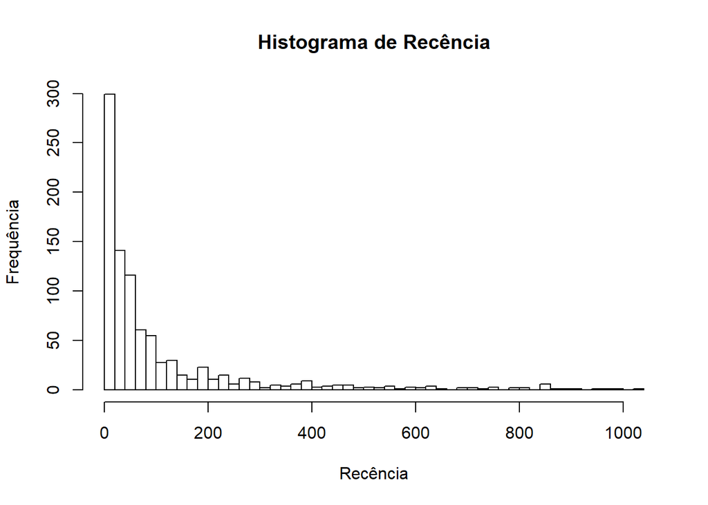

```r
hist(cust_df$Recency,
     breaks = 50,
     main = "Histograma de Recência",
     xlab = "Recência",
     ylab = "Frequência")
```

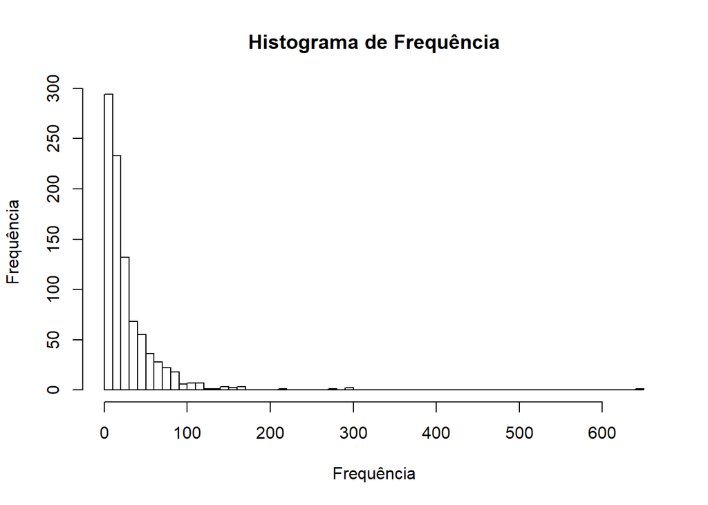

```r
hist(cust_df$Frequency,
     breaks = 50,
     main = "Histograma de Frequência",
     xlab = "Frequência",
     ylab = "Frequência")
```

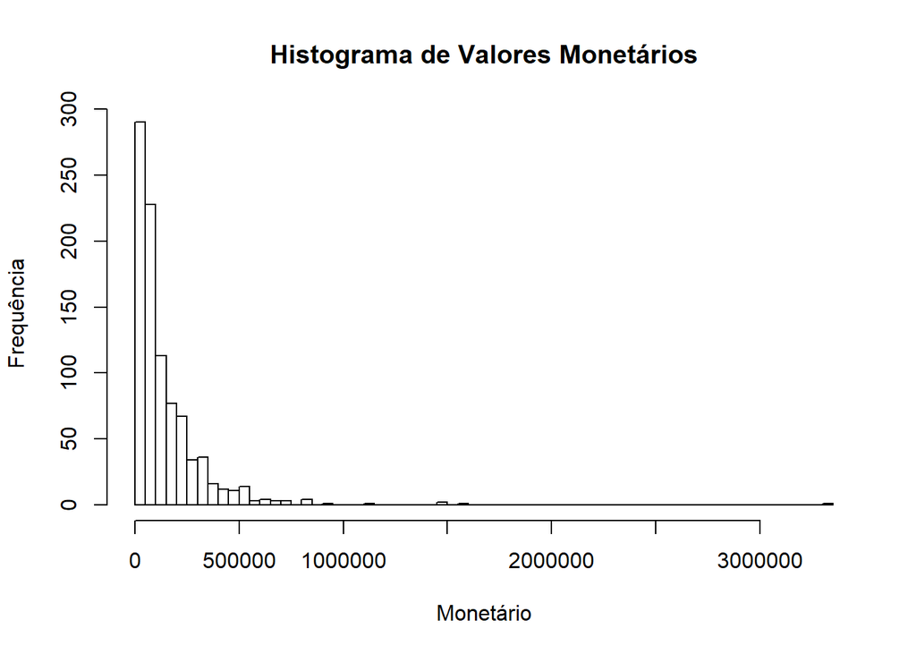

```r
hist(cust_df$Monetary,
     breaks = 50,
     main = "Histograma de Valores Monetários",
     xlab = "Monetário",
     ylab = "Frequência")
```

### 3.1 Determinação de Percentis

Para determinar os parâmetros *RFM* usa-se os quartis ou percentis. No presente caso, dividir-se-á o conjunto de dados em $05$ partes iguais, ou seja divisão em $20\%$ cada parte. A ideia é encontrar os Top $20\%$ clientes mais valiosos.

```r
quantile(cust_df$Recency, probs = seq(0, 1, 0.20)) %>% pander()
```

| 0% | 20% | 40% | 60% | 80% | 100% |
| --- | --- | --- | --- | --- | --- |
| 1 | 10 | 28 | 60 | 145 | 1026 |

```r
quantile(cust_df$Frequency, probs = seq(0, 1, 0.20)) %>% pander()
```

| 0% | 20% | 40% | 60% | 80% | 100% |
| --- | --- | --- | --- | --- | --- |
| 1 | 6 | 14 | 22 | 43 | 644 |

```r
quantile(cust_df$Monetary, probs = seq(0, 1, 0.20)) %>% pander()
```

| 0% | 20% | 40% | 60% | 80% | 100% |
| --- | --- | --- | --- | --- | --- |
| 556 | 29757 | 68176 | 109592 | 219327 | 3342290 |

### 3.2 Determinação de *RFM score*

Baseando-se no príncipio de pareto de que $80\%$ dos seus negócios vêm de $20\%$ dos seus clientes. O *RFM* ajuda a identificar clientes com maior probabilidade de responder a promoções, segmentando-os em várias categorias.

Usar-se-á o percentil $20$ para se determinar os *RFM score*, i.e, dividir-se-á a série de dados em $05$ partes iguais. Assim sendo, os Top $20$ ficam com pontuação máxima de $05$ pontos, enquanto que os últimos $20\%$ ficam com a pontuação mínima de $01$ ponto. Para análise do parâmetro **R** *(Recency)*, a ordem deve ser invertida, i.e, os valores baixos levam pontuação máxima ($05$ pontos) e os valores altos pontuação mínima ($01$ ponto).

Portanto, o melhor cliente tem a pontuação máxima de $555$ *(RFM score)* e o pior com pontuação mínima de $111$ *(RFM score)* pontos.

```r
# Cálculo de RFM scores
rfm_data <- cust_df

rfm_data <-
    rfm_data %>%
    mutate(
        R = ntile(desc(Recency), 5),
        F = ntile(Frequency, 5),
        M = ntile(Monetary, 5)
    )

rfm_data$RFM <- rfm_data$R * 100 + rfm_data$F * 10 + rfm_data$M

rfm_data %>% head(10) %>% pander()
```

| CustomerID | Recency | Date_Purchase | Frequency | Monetary | R | F | M | RFM |
| --- | --- | --- | --- | --- | --- | --- | --- | --- |
| 12347 | 14 | 994 | 31 | 178001 | 4 | 4 | 4 | 444 |
| 12348 | 156 | 1031 | 17 | 76776 | 1 | 3 | 3 | 133 |
| 12370 | 11 | 1093 | 91 | 502537 | 4 | 5 | 5 | 455 |
| 12377 | 14 | 1079 | 43 | 222580 | 4 | 4 | 5 | 445 |
| 12386 | 236 | 1042 | 8 | 34223 | 1 | 2 | 2 | 122 |
| 12395 | 4 | 996 | 31 | 159825 | 5 | 4 | 4 | 544 |
| 12417 | 123 | 1083 | 11 | 63296 | 2 | 2 | 2 | 222 |
| 12427 | 295 | 1079 | 10 | 66185 | 1 | 2 | 2 | 122 |
| 12429 | 16 | 1083 | 20 | 103905 | 4 | 3 | 3 | 433 |
| 12431 | 70 | 1095 | 24 | 130577 | 2 | 4 | 4 | 244 |

Note que, quanto menor for o parâmetro *Recency* maior será o *R score* e *RFM score*. Assim sendo, os clientes com maior *RFM score* das $10$ primeiras observações para o caso em estudo são: *CustomerID* - $12347, 12370, 12377, 12395$ e os com menor *RFM score* são *CustomerID* - $12386$ e $12427$.

### 3.3 Definição de Segmentos

Neste caso de estudo, aplicou-se *RFM score Analysis* para segmentação de clientes. Este método exige que haja cuidadosa precisão ao definir e analisar os intervalos dos *RFM scores*, de forma que se assegure que não haja duplicação dos clientes em vários segmentos, i.e, cada cliente deve pertence exclusivamente a um único segmento.

Em *RFM* a segmentação de clientes pode ser feita conforme a tabela abaixo:

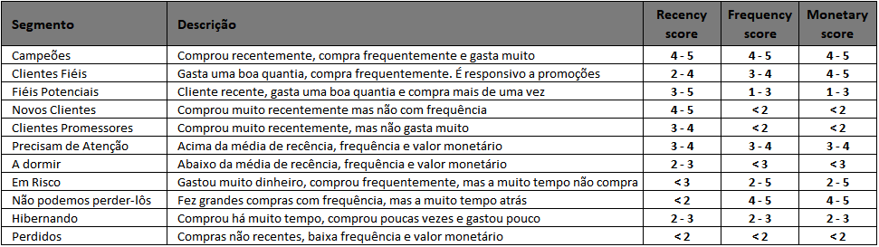

**Tabela 1: Classificação e Segmentação de Clientes**

Em alguns artigos sugerem a definição dos segmentos com base no bom senso e na natureza do negócio, contundo usando a *Tabela 1*, pode-se aplicar a classificação e segmentação abaixo que é aplicável para qualquer negócio.

```r
# Definição de segmentação dos clientes por grupos
rfm_data$Segment <- NA

rfm_data$Segment[which(rfm_data$RFM == 111)] <- 'Clientes Perdidos'
rfm_data$Segment[which(rfm_data$RFM > 111)] <- 'Hibernando'
rfm_data$Segment[which(rfm_data$RFM >= 222)] <- 'A dormir'
rfm_data$Segment[which(rfm_data$RFM >= 333)] <-'Fieis Potenciais'
rfm_data$Segment[which(rfm_data$RFM >= 444)] <- 'Campeoes'

# 2nd round

rfm_data$Segment[which(rfm_data$Segment == 'Fieis Potenciais' &
                           (rfm_data$F >= 4))] <- 'Clientes Fieis'

rfm_data$Segment[which(rfm_data$Segment == 'A dormir' &
                           (rfm_data$M >= 4))] <- 'Precisam de Atencao'

rfm_data$Segment[which(rfm_data$Segment == 'Hibernando' &
                           (rfm_data$F >= 4 & rfm_data$M >= 4))] <- 'Nao perder-los'

rfm_data[, -c(3, 6,7,8)] %>%
    head(10) %>% pander()
```

| CustomerID | Recency | Frequency | Monetary | RFM | Segment |
| --- | --- | --- | --- | --- | --- |
| 12347 | 14 | 31 | 178001 | 444 | Campeoes |
| 12348 | 156 | 17 | 76776 | 133 | Hibernando |
| 12370 | 11 | 91 | 502537 | 455 | Campeoes |
| 12377 | 14 | 43 | 222580 | 445 | Campeoes |
| 12386 | 236 | 8 | 34223 | 122 | Hibernando |
| 12395 | 4 | 31 | 159825 | 544 | Campeoes |
| 12417 | 123 | 11 | 63296 | 222 | A dormir |
| 12427 | 295 | 10 | 66185 | 122 | Hibernando |
| 12429 | 16 | 20 | 103905 | 433 | Fieis Potenciais |
| 12431 | 70 | 24 | 130577 | 244 | Precisam de Atencao |

**Lembre-se**, um cliente não pode pertencer simultâneamente a mais de um segmento. Entrentanto, para assegurar que os critérios definidos abrangem todos os clientes e que nenhum ficou sem classificação e segmento, verifcar-se-á de seguinte forma:

```r
rfm_data[is.na(rfm_data$Segment),]
```

| CustomerID | Recency | Date_Purchase | Frequency | Monetary | R | F | M | RFM | Segment |
| --- | --- | --- | --- | --- | --- | --- | --- | --- | --- |

### 3.4 Contagem de Clientes por Segmentos

Nesta etapa, mostra-se a distribuição dos clientes por segmentos.

```r
# Re-ordenar os segmentos em função as cenários definidos
rfm_data$Segment <-
    factor(
        x = rfm_data$Segment,
        levels = c(
            'Clientes Perdidos',
            'Hibernando',
            'Nao perder-los',
            'A dormir',
            'Precisam de Atencao',
            'Fieis Potenciais',
            'Clientes Fieis',
            'Campeoes'
        )
    )
```

```r
# Tabela de Frequências
freqTable <-
    rfm_data %>%
    count(Segment) %>%
    rename(Segmento = Segment, Contagem = n)

freqTable$Racio <- prop.table(table(rfm_data$Segment))*100
```

```r
freqTable %>% pander()
```

| Segmento | Contagem | Racio |
| --- | --- | --- |
| Clientes Perdidos | 119 | 12.92 |
| Hibernando | 99 | 10.75 |
| Nao perder-los | 2 | 0.2172 |
| A dormir | 170 | 18.46 |
| Precisam de Atencao | 40 | 4.343 |
| Fieis Potenciais | 114 | 12.38 |
| Clientes Fieis | 87 | 9.446 |
| Campeoes | 290 | 31.49 |

## 4.0 Gráficos de Segmentação

Aplicar-se-á 2 gráficos para visualização dos segmentos definidos nos dados em estudo.

### 4.1 Treemap (recomendado)

```r
hctreemap2(
    data = freqTable,
    group_vars = "Segmento",
    size_var = "Contagem",
    color_var = "Contagem"
    )
```

[interactive chart not shown]

### 4.2 Gráfico de barras

O gráfico de barras mostra o número de clientes classificados por segmento.

```r
highchart() %>%
    hc_add_series(
        data = freqTable,
        type = 'column',
        hcaes(x = Segmento, y = Contagem),
        dataLabels = list(align = "center", enabled = TRUE,
                          style = list(
                                      fontWeight = "bold",
                                      color = "#4D4D4D",
                                      textOutline = NULL
                                      )
                          ),
        name = 'Segmentos'
    ) %>%
    hc_xAxis(categories = unique(freqTable$Segmento)) %>%
    hc_yAxis(title = list(text = "No de Clientes"))
```

[interactive chart not shown]

## 5.0 Conclusão

No presente trabalho aplicou-se *RFM score Analysis* para classificar e segmentar clientes de uma determinada empresa representante de várias marcas de roupas e acessórios, usando a linguagem de programção **R**.

Envolvidos $921$ clientes, com mais de $25,000$ transações para o estudo, assim foi a segmentação usando esta técnica: $31.49\%$ dos clientes, correspondentes as $290$ foram classificados como **Campeões**, estes são clientes que tem *RFM score* maior e igual a 444 pontos. Outro grupo com maior porcentagem segmentada é o **About To Sleep** *(A dormir)* que apresenta $18.46\%$ dos clientes, entretanto, esta linha, precisará de um trabalho árduo de forma a recuperar-los e oferecer uma promoção.

Uma técnica similar a esta que desafio a usarem é *Cluster Analysis* **(Análise de Agrupamentos)** para efeitos comparativos de aplicabilidade.

## 6.0 Referências

1. Tukey, John (1977).*Exploratory Data Analysis*.Addison-Wesley Publishing Company;
2. https://cran.r-project.org/web/packages/rfm/vignettes/rfm-customer-level-data.html;
3. https://www.r-bloggers.com/customer-segmentation-using-rfm-analysis/;
4. https://medium.com/docsapp-product-and-technology/rfm-segmentation-in-r-using-didroorfm-package-f8a03a223b6b.